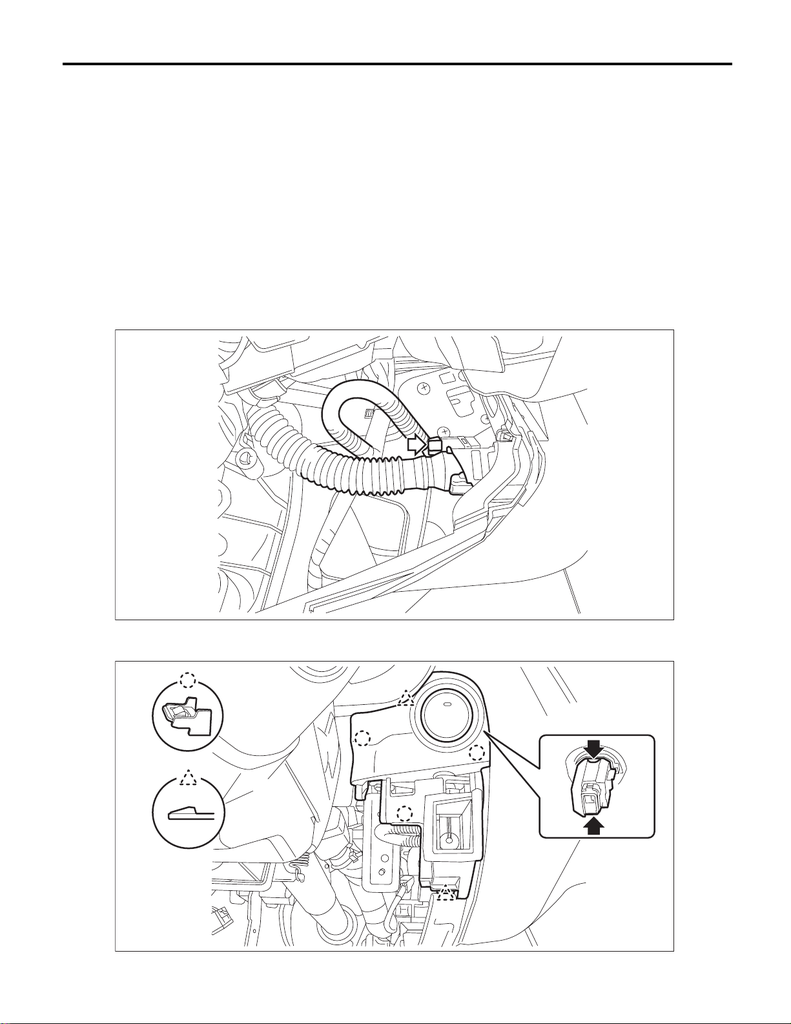

SL-106

Push Button Ignition Switch

SECURITY AND LOCKS

36.Push Button Ignition Switch

A: REMOVAL

CAUTION:

Before handling the airbag module, refer to “CAUTION” of “General Description” in “AIRBAG SYS-

TEM”. <Ref. to AB-9, CAUTION, General Description.>

1) Disconnect the ground cable from battery and wait for at least 60 seconds before starting work. <Ref. to

NT-5, BATTERY, NOTE, Note.>

NOTE:

For models other than STI model, disconnect the ground terminal from battery sensor.

2) Remove the cover assembly - instrument panel LWR driver. <Ref. to EI-61, REMOVAL, Instrument Panel

Lower Cover.>

3) Remove the knee airbag module. <Ref. to AB-35, REMOVAL, Knee Airbag Module.>

4) Remove the push button ignition switch.

(1) Disconnect the connector, and remove the aspirator hose.

(2) Release the claws, and then remove the panel - switch.

(3) Release the claws, and then remove the push button ignition switch from the panel - switch.

AC-02714

SL-01599

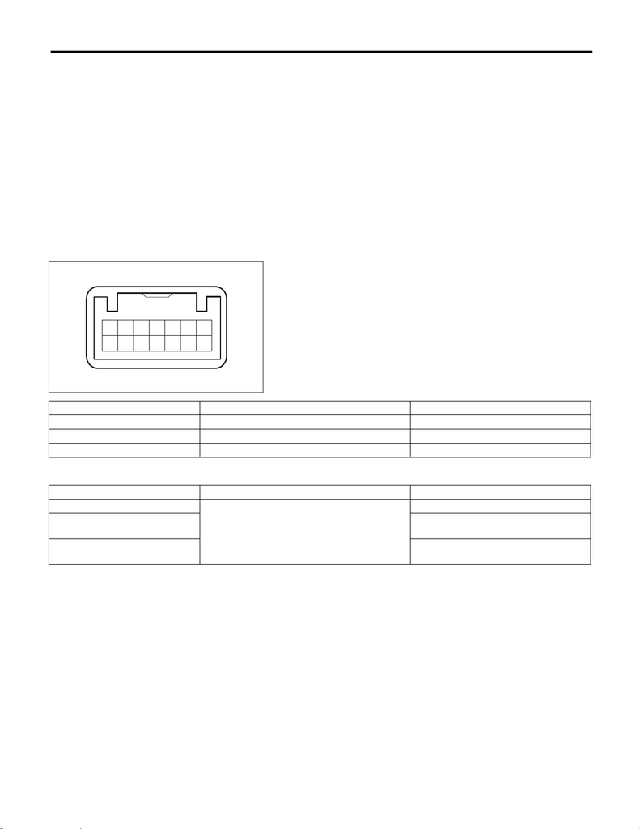

SL-107

Push Button Ignition Switch

SECURITY AND LOCKS

B: INSTALLATION

CAUTION:

Before handling the airbag module, refer to “CAUTION” of “General Description” in “AIRBAG SYS-

TEM”. <Ref. to AB-9, CAUTION, General Description.>

1) Install the push button ignition switch to the cover assembly - instrument panel LWR driver INN.

2) Install the cover assembly - instrument panel LWR driver.

3) Connect the battery ground terminal. <Ref. to NT-5, BATTERY, NOTE, Note.>

NOTE:

For models other than STI model, connect the ground terminal to battery sensor.

C: INSPECTION

1) Check the continuity between the connectors.

Preparation tool:

Circuit tester

2) Check the push button ignition switch operation when battery voltage is applied between the connectors.

3) Replace the push button ignition switch if the inspection result is not within the standard value.

SL-02883

Terminal No. Inspection conditions Specification

4 (COM) — 5 (GND) Always Continuity exists

7 (SSW1) — 5 (GND) Push button ignition switch released → pressed Continuity exists

2 (SSW2) — 5 (GND) Push button ignition switch released → pressed Continuity exists

Terminal No. Inspection conditions Specification

11 (SWIL) — 5 (GND)

Connect battery to the terminals

Goes off → Red switch illumination light

12 (INDS) — 5 (GND)

Turns off → Switch indicator lights in

green

13 (INDW) — 5 (GND)

Turns off → Switch indicator lights in

orange